# Validação Cruzada

Bruna Wundervald

# Definição

- Na falta de uma grande base de dados de teste, utilizados para estimar a taxa de erro do algoritmo, algumas técnicas podem ser aplicadas para quantificar esta taxa usando os próprios dados disponíveis para treino. Uma destas técnicas é a validação cruzada. Ela consiste em calcular a taxa de erro em um certo subconjunto dos dados de treino, separado previamente, ou seja, que não participa do aprendizado do algoritmo.

## Holdout

- A técnica conhecida como *holdout* consiste na divisão dos dados em treino e validação, dada alguma proporção pré-definida, como *80-20* (80% dos dados para treino e 20% para validação) ou *70-30*. O algoritmo aprende com o subconjunto de treino e o restante dos dados é usado para predição. O erro proveniente dos dados de validação fornece uma estimativa do erro de teste, que é normalmente quantificado pelo **erro quadrático médio** para variáveis contínuas e pela **taxa de classificação incorreta** no caso de variáveis discretas.

## K-fold

- A técnica de validação cruzada chamada de “k-fold” (‘k dobras’) é quando faz-se a divisão dos dados de treino em *k* partes iguais, reservando *k-1* partes para o treino e *1* parte para o cálculo da medida de erro. Este processo é feito para cada uma das *k* partes, isto é, todas as partes passam pelo estado de “treino” e “validação”, e os *k* resultados obtidos para o erro são combinados através de:
  $$CV_{k} = \sum_{k = 1}^{K} \frac{n_k}{n} EQM_k,$$
  Com $EQM_k = \sum_{i \in C_k} \frac{(y_i - \hat y_i)^2}{n_k}$, para o caso de variáveis contínuas e:

$$CV_{k} = \sum_{k = 1}^{K} \frac{n_k}{n} Err_k,$$

Onde $Err_k = \sum_{i \in C_k} \frac{(y_i \neq \hat y_i)}{n_k}$, para quando a variável é discreta, representando a taxa de classificação incorreta.

- O caso específico de *n-fold* é conhecido como Leave-One-Out. Este nome vem de que em cada etapa do processo, apenas uma observação é deixada de fora do treino.

# Exemplo de Utilização

## Validação cruzada para encontrar o $\lambda$ ótimo na utilização de suavizadores por Kernel.

### Suavizadores por Kernel

- Problemas que envolvem modelagem são aqueles nos quais temos interesse em estimar a relação entre uma ou mais variáveis *resposta*, denotadas por $y$ e uma ou mais variáveis explicativas $x$. Uma das abordagens possíveis na resolução deste tipo de problema é a suavização de uma curva por Kernel.
- Em geral, um Kernel suavizador define um conjunto de pesos ${W_i(x)}_{i=1}^{n}$ para cada $x$, e
  $$\hat f(x) = \sum_{i = 1}^{n} W_i(x) y_i.$$
- Para um Kernel suavizador, temos que a sequência de pesos ${W_i(x)}_{i=1}^{n}$ é representada ao descrever a forma da função de pesos $W_i(x)$ por uma função de densidade, com um parâmetro de escala que ajusta o tamanho e forma dos pesos perto de $x$. Assim, refere-se à essa função de forma como um *kernel K*, onde:
  $$\int K(u)d(u) = 1.$$
- O parâmetro de escala denominado por $\lambda$ produz a sequência de pesos:
  $$W_{hi}(x) = \frac{K \frac{(x - x_i)}{\lambda}} {\sum_{i = 1}^{n} K \frac{(x - x_i)}{\lambda}}$$
- É crucial para a performance do estimador que a largura de banda, ou $\lambda$, seja bem definida. Uma das abordagens mais utilizadas para encontrar este valor é a LOOCV (Leave-One-Out Cross Validation), de forma a minimizar:
  $$EQ = \sum_{i = 1}^{n} (y_i - \hat f(x_i))^2 + \lambda \int \hat f''(x_i) dx$$

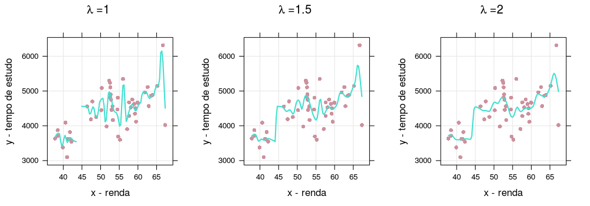

```r
library(labestData)
library(lattice)
library(latticeExtra)

da <- data.frame(y = PaulaEx1.13.19$renda,
                 x = PaulaEx1.13.19$estud)

# Qual o valor ótimo para o lambda?
p1 <- xyplot(y ~ x, data = da, type = c("p", "g"),
             col = "pink3", xlab = "x - renda",
             ylab = "y - tempo de estudo",
             pch = 16,
             main = expression(lambda~"=1"))+
  layer(panel.lines(ksmooth(da$x, da$y, "normal", 1),
                    lwd = 2,
                    col = "turquoise"))

p2 <- xyplot(y ~ x, data = da, type = c("p", "g"),
             col = "pink3", xlab = "x - renda",
             ylab = "y - tempo de estudo",
             pch = 16,
             main = expression(lambda~"=1.5"))+
  layer(panel.lines(ksmooth(da$x, da$y, "normal", 1.5),
                    lwd = 2,
                    col = "turquoise"))

p3 <- xyplot(y ~ x, data = da, type = c("p", "g"),
             col = "pink3", xlab = "x - renda",
             ylab = "y - tempo de estudo",
             pch = 16,
             main = expression(lambda~"=2"))+
  layer(panel.lines(ksmooth(da$x, da$y, "normal", 2),
                    lwd = 2,
                    col = "turquoise"))


print(p1, position = c(0, 0, 1/3, 1), more = TRUE)
print(p2, position = c(1/3, 0, 2/3, 1), more = TRUE)
print(p3, position = c(2/3, 0, 1, 1))
```

```r
#---------------------
(n <- nrow(da))
```

```
[1] 50
```

```r
k <- 5

da$i <- ceiling((1:n)/(n/k))

# Parte os dados em k conjuntos disjuntos.
das <- split(da, f = da$i)

cen <- expand.grid(fold = 1:k,
                   l = 3:250)

kfol <- mapply(f = cen$fold,
               d = cen$l,
               FUN = function(f, d) {
                   j <- da$i != f

                   b <- ksmooth(subset(da, j)$x,
                                subset(da, j)$y,
                                "normal", bandwidth = d)

                   # Erro de treinamento
                   cvt <- sum((subset(da, j)$y - b$y)^2,
                              na.rm = TRUE)/length(subset(da, j)$y)
                  #--------------------
                  # Erro de validação
                   p <- b$y[which.min(abs(b$x-das[[f]]$x))]
                   cvval <- crossprod((das[[f]]$y -
                                        p)^2)/length(das[[f]]$y)
                   return(c(cvt = cvt, cvval = cvval))
               })

kfol <- cbind(cen, as.data.frame(t(kfol)))
str(kfol)
```

```
'data.frame':   1240 obs. of  4 variables:
 $ fold : int  1 2 3 4 5 1 2 3 4 5 ...
 $ l    : int  3 3 3 3 3 4 4 4 4 4 ...
 $ cvt  : num  1274371 1571846 1545997 1693674 1892323 ...
 $ cvval: num  9.15e+12 3.67e+11 6.57e+11 7.58e+11 6.96e+10 ...
```

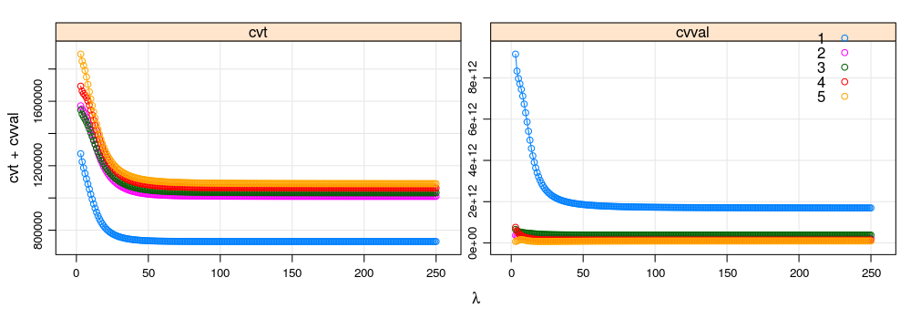

```r
xyplot(cvt + cvval ~  l, groups = fold , data = kfol,
       auto.key = list(corner = c(0.95, 0.95)),
       type = c("p", "g", "o"),
       scales = "free",
       xlab = expression(lambda))
```

```r
#-------------
which.min(kfol$cvval)
```

```
[1] 5
```

```r
kfol[5,] # lambda = 3
```

```
  fold l     cvt       cvval
5    5 3 1892323 69568605954
```

```r
#-----------------------------------------------------------------------
# leave-one-out

# Cenários
cen <- expand.grid(fold = 1:n,
                   l = 3:15)

# Obtendo os erros para cada cenário
nfol <- mapply(f = cen$fold,
               d = cen$l,
               FUN = function(f, d) {
                 # browser()
                 b <- ksmooth(da[-f,]$x,
                                da[-f,]$y,
                                "normal", bandwidth = d)

                   # Erro de treinamento
                   cvt <- sum((da[-f]$y - b$y)^2,
                              na.rm = TRUE)/length(da[-f]$y)
                  #--------------------
                  # Erro de validação
                   p <- b$y[which.min(abs(b$x-da[f, ]$x))]

                   cvval <- (p - da$y[f])^2
                   return(c(cvt = cvt, cvval = cvval))

               })

nfol <- cbind(cen, as.data.frame(t(nfol)))
which.min(nfol$cvval)
```

```
[1] 585
```

```r
nfol[585,] # lambda = 14
```

```
    fold  l     cvt    cvval
585   35 14 1042973 5.752992
```

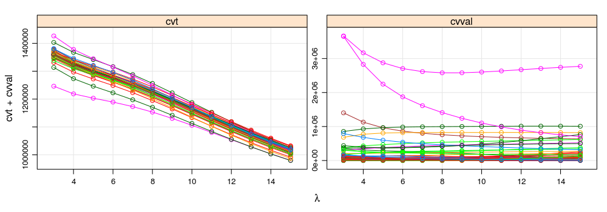

```r
xyplot(cvt + cvval ~  l, groups = fold , data = nfol,
       type = c("p", "g", "o"),
       scales = "free",
       xlab = expression(lambda))
```